# Instrucciones

1.- Función de Métricas de Desempeño. (20%)

Genera una función en python que reciba un data frame con la evolución histórica de n cantidad de estrategías de inversión y calcule todas las métricas de desempeño vistas en las dos clases anteriores (Rendimiento, Volatilidad, Ratio de Sharpe, Downside, Upside, Omega, Beta, Alfa de Jensen, Ratio de Treynor, Ratio de Sortino).

2.- Backtesting de Portafolio. (50%)

Asume que quieres invertir en un portafolio compuesto por las siguientes acciones mexicanas: LIVEPOLC1.MX, KOFUBL.MX, CEMEXCPO.MX, CHDRAUIB.MX, CUERVO.MX, LABB.MX, RA.MX. Debido a que no sabes como ponderarlos, decides realizar el backtesting para el portafolio para cuatro estrategias de Asset Allocation: Mínima Varianza, Máximo de Sharpe, Semivarianza Target y Omega. Realiza el backtesting utilizando datos para simulación del 23-06-2024 hasta el 23-06-2025, toma un período anterior con el mismo horizonte temporal para optimizar las ponderaciones. Recuerda siempre comparar con una estrategia de inversión pasiva, en este caso la opción lógica es el IPC México. Gráfica la evolución histórica de las cinco alternativas de inversión. Con los resultados del backtesting histórico calcula e interpreta las métricas de desempeño para las cinco alternativas de estrategias de inversión simuladas.

3.- Selección de Estrategia de Inversión. (20%)

Utilizando los resultados de tu backtesting y las métricas de desempeño, selecciona una estrategia de inversión. Realiza una conclusión clara, breve y robusta de porque es la mejor estrategia PARA TI, apoyate en las métricas obtenidas y en tu perfil de aversión al riesgo.

4.- Calculo de Pesos para Portafolio Real. (10%)

En base a la estrategia de Asset Allocation seleccionada en el punto anterior, calcula los pesos eficientes y la cantidad de acciones que utilizarías para invertir en la realidad en tu portafolio. Recuerda tomar la ventana de datos más reciente, en función del horizonte temporal tomado.

```python
import pandas as pd
import numpy as np
import yfinance as yf
import matplotlib.pyplot as plt
from scipy.optimize import minimize
```

```python
def port_min_var(rets): # los pesos que hacen que el riesgo TOTAL sea lo más pequeño posible

    # matriz de covarianza de los rendimientos
    cov = rets.cov()
    # cuantos activos hay
    n = len(rets.columns)
    # varianza del portafolio / función objetivo
    var = lambda w: w.T @ cov @ w
    # pesos iniciales
    w0 = np.ones(n)/n
    # cotas
    bounds =[(0, 1)] * n
    # restricciones, tiene que sumar 1
    constraint =lambda w: sum(w)-1

    result = minimize(
        fun=var,
        x0=w0,
        bounds=bounds,
        constraints={'fun': constraint, 'type': 'eq'},
        tol=1e-20
    )

    return result.x
```

```python
def max_sharpe(rets, rf):
    #rendimientos
    E=rets.mean()
    # matriz de covarianza
    cov=rets.cov()

    n_assets = len(rets.columns)

    r_sharpe = lambda w: -((w.T @ E - rf/252) / np.sqrt(w.T @ cov @ w)) # tasa se hace diaria si los redimientos son diarios
    #pesos iniciales
    w0=np.ones(n_assets)/n_assets
    #cotas
    bounds=[(0, 1)]*n_assets

    constraint=lambda w: sum(w)-1

    result = minimize(
        fun=r_sharpe,
        x0=w0,
        bounds=bounds,
        constraints={'fun': constraint, 'type': 'eq'},
        tol=1e-20
    )

    return result.x
```

```python
def semi_var_target(returns: pd.DataFrame, returns_b: pd.DataFrame, corr: pd.DataFrame):

    # Alinea los datos de los rendimientos y el benchmark
    returns, returns_b = returns.align(returns_b, join='inner', axis=0)

    # Calcula la diferencia entre los rendimientos del portafolio y el benchmark
    diff_returns = returns - returns_b.values

    # rendimientos por debajo del benchmark
    downside_returns = diff_returns[diff_returns < 0].fillna(0)

    # Calcula el riesgo a la baja (desviación estándar de las pérdidas relativas)
    downside_risk = np.array(downside_returns.std())

    # Crea la matriz de semivarianza
    semi_var_matrix = corr * (downside_risk.reshape(len(returns.columns), 1) @ downside_risk.reshape(1, len(returns.columns))
    )

    # Define la función objetivo que es minimizar la semivarianza del portafolio
    target = lambda w: w.T @ semi_var_matrix @ w

    n = len(returns.keys())

    # Pesos iniciales iguales para todos los activos
    w_inicial = np.ones(n) / n

    # Límites de los pesos
    bounds = [(0, 1)] * n

    # Tolerancia
    tol = 1e-20

    # Restricción
    constraint = lambda w: np.sum(w) - 1

    # Optimización para minimizar la semivarianza
    trg = minimize(
        fun=target,
        x0=w_inicial,
        bounds=bounds,
        constraints={'fun': constraint, 'type': 'eq'},
        tol=tol
    )

    # pesos óptimos
    w_target = trg.x

    # Diccionario
    return dict(zip(returns.columns, w_target))
```

```python
def max_omega(rets: pd.DataFrame):
    n = len(rets.columns)
    w_inicial = np.ones(n) / n
    bounds = [(0, 1)] * n
    tol = 1e-20

    rets_below_zero = rets[rets < 0].fillna(0)
    rets_above_zero = rets[rets > 0].fillna(0)
    upside_risk=rets_above_zero.std()
    downside_risk = rets_below_zero.std()

    omega_ind = upside_risk / downside_risk

    omega_neg = lambda w: -np.sum(w * omega_ind)

    constraints = {'fun': lambda w: np.sum(w) - 1, 'type': 'eq'}

    result = minimize(
        fun=omega_neg,
        x0=w_inicial,
        bounds=bounds,
        constraints=constraints,
        tol=tol
    )

    w_omega = result.x
    return dict(zip(rets.columns, w_omega))
```

```python
def backtesting(prices: pd.DataFrame, benchmark: pd.DataFrame, weights: dict, capital: float):

    rets_assets = prices.pct_change().dropna()
    rets_benchmark = benchmark.pct_change().dropna()

    df = pd.DataFrame(index=rets_assets.index)

    # evolución
    for strategy in weights.keys():
        # para benchmark
        if strategy == 'benchmark':
            temp = rets_benchmark + 1
            temp.iloc[0]=capital
            temp = temp.cumprod()
            df[strategy] = temp.values

        else:
            temp = (rets_assets * weights.get(strategy)).sum(axis=1)+1
            temp.iloc[0]=capital
            temp = temp.cumprod()
            df[strategy] = temp.values

    # Gráfica
    plt.figure(figsize=(12,6))
    plt.plot(df, label=df.keys())
    plt.title('Backtesting of Strategies')
    plt.xlabel('Date')
    plt.ylabel('Portafolio Value')
    plt.legend()
    plt.show()


    return df
```

### Función de Métricas de Desempeño

```python
def metricas_desempeño(df, rf): # si tus datos los vas a anualizar, entonces el rf también anual !!!
    # Rendimientos
    rets= df.pct_change().dropna()

    # Matriz de Covarianza de los rendimientos
    cov_df = rets.cov()

    # Dataframe
    metricas_de_desempeño = pd.DataFrame(index=rets.columns)

    # Rendimiento
    metricas_de_desempeño['Rendimiento promedio anual'] = R_p = rets.mean()*252*100 # todo aquí esta en anual (cuidado)

    # Volatilidad
    metricas_de_desempeño['Volatilidad Anual'] = vol_a = rets.std()*np.sqrt(252)*100

    # Ratio de Sharpe
    metricas_de_desempeño['Ratio de Sharpe'] = (R_p - rf) / vol_a

    # Downside
    metricas_de_desempeño['Downside Risk'] = downside = rets[rets < 0].std() * np.sqrt(252) * 100

    # Upside
    metricas_de_desempeño['Upside Risk'] = upside = rets[rets > 0].std() * np.sqrt(252) * 100

    # Omega
    metricas_de_desempeño['Omega'] = omega = upside / downside

    # Beta
    covs = cov_df['Benchmark']
    varianza_market = covs['Benchmark']
    metricas_de_desempeño['Beta'] = beta = covs / varianza_market

    # Alfa de Jensen
    R_m = rets['Benchmark'].mean() * 252 * 100
    metricas_de_desempeño['Alpha']=alpha_Jensen = R_p - (rf + beta * (R_m - rf))

    # Ratio de Treynor
    metricas_de_desempeño['Ratio de Treynor'] = (R_p - rf) / beta

    # Ratio de Sortino
    metricas_de_desempeño['Ratio de Sortino'] = (R_p - rf) / downside

    return metricas_de_desempeño.T
```

```python
tickers = ['LIVEPOLC-1.MX', 'KOFUBL.MX', 'CEMEXCPO.MX', 'CHDRAUIB.MX', 'CUERVO.MX', 'LABB.MX', 'RA.MX']
```

```python
opt_prices = yf.download(tickers, start='2023-06-23', end='2024-06-23', progress=False)['Close']
opt_prices
```

| Ticker Date | CEMEXCPO.MX | CHDRAUIB.MX | CUERVO.MX | KOFUBL.MX | LABB.MX | LIVEPOLC-1.MX | RA.MX |
| --- | --- | --- | --- | --- | --- | --- | --- |
| 2023-06-23 | 11.755546 | 96.374352 | 40.408039 | 138.768982 | 12.805666 | 101.060478 | 108.692963 |
| 2023-06-26 | 11.706026 | 95.263351 | 40.350449 | 136.604202 | 12.524719 | 99.296303 | 111.160431 |
| 2023-06-27 | 11.923905 | 95.506989 | 41.175888 | 134.597351 | 12.533783 | 100.747482 | 111.151520 |
| 2023-06-28 | 11.785255 | 95.068436 | 40.168087 | 133.528915 | 12.434093 | 99.154037 | 109.752998 |
| 2023-06-29 | 11.854581 | 94.045151 | 40.552010 | 132.460464 | 12.415967 | 99.239395 | 111.525650 |
| ... | ... | ... | ... | ... | ... | ... | ... |
| 2024-06-17 | 11.982553 | 120.246368 | 33.974632 | 151.417328 | 15.403941 | 119.104691 | 120.702232 |
| 2024-06-18 | 11.893056 | 121.239891 | 33.974632 | 152.491364 | 16.396221 | 120.044052 | 124.073547 |
| 2024-06-19 | 11.893056 | 122.233429 | 34.663830 | 151.707596 | 16.500172 | 119.540489 | 124.082909 |
| 2024-06-20 | 11.704121 | 123.226952 | 33.994045 | 150.323959 | 16.069983 | 119.036911 | 124.007980 |
| 2024-06-21 | 11.326247 | 124.938576 | 33.586349 | 146.666489 | 15.897908 | 124.924843 | 123.614670 |

251 rows × 7 columns

```python
bt_prices = yf.download(tickers,  start='2024-06-23', end='2025-06-23', progress=False)['Close']
bt_prices
```

| Ticker Date | CEMEXCPO.MX | CHDRAUIB.MX | CUERVO.MX | KOFUBL.MX | LABB.MX | LIVEPOLC-1.MX | RA.MX |
| --- | --- | --- | --- | --- | --- | --- | --- |
| 2024-06-24 | 11.385911 | 126.384598 | 33.042755 | 147.063202 | 16.356777 | 122.639389 | 123.745773 |
| 2024-06-25 | 11.485352 | 125.912430 | 32.741837 | 149.559570 | 16.366339 | 122.988014 | 124.317024 |
| 2024-06-26 | 11.535071 | 124.151627 | 32.256485 | 148.504898 | 16.012627 | 126.445259 | 128.606079 |
| 2024-06-27 | 11.654400 | 124.515587 | 32.372971 | 151.417343 | 16.194263 | 127.665436 | 126.236809 |
| 2024-06-28 | 11.634512 | 124.722160 | 32.033226 | 152.259140 | 16.423698 | 127.326492 | 128.259583 |
| ... | ... | ... | ... | ... | ... | ... | ... |
| 2025-06-16 | 12.937180 | 144.479996 | 22.430000 | 179.647781 | 20.393236 | 91.163811 | 158.020004 |
| 2025-06-17 | 12.929513 | 142.199997 | 22.120001 | 177.254150 | 20.932480 | 91.538727 | 158.380005 |
| 2025-06-18 | 13.029278 | 145.190002 | 21.760000 | 174.694458 | 20.373629 | 91.223007 | 155.020004 |
| 2025-06-19 | 12.879630 | 144.550003 | 22.120001 | 179.755249 | 20.677565 | 91.094749 | 159.979996 |
| 2025-06-20 | 12.909559 | 146.110001 | 23.049999 | 176.882904 | 20.295193 | 92.722672 | 157.250000 |

249 rows × 7 columns

```python
benchmark = yf.download(['^MXX'], start='2024-06-23', end='2025-06-23', progress=False)['Close']
benchmark
```

| Ticker Date | ^MXX |
| --- | --- |
| 2024-06-24 | 52512.910156 |
| 2024-06-25 | 52604.050781 |
| 2024-06-26 | 52468.011719 |
| 2024-06-27 | 52310.960938 |
| 2024-06-28 | 52440.019531 |
| ... | ... |
| 2025-06-16 | 57046.851562 |
| 2025-06-17 | 56676.820312 |
| 2025-06-18 | 56729.570312 |
| 2025-06-19 | 56068.160156 |
| 2025-06-20 | 56264.691406 |

249 rows × 1 columns

```python
opt_rets = opt_prices.pct_change().dropna()
corr = opt_rets.corr()
```

```python
rets_b = benchmark.pct_change().dropna()
```

```python
rets_bt = bt_prices.pct_change().dropna()
```

```python
w_minvar = port_min_var(opt_rets)
dict(zip(opt_rets.columns, w_minvar))
```

```
{'CEMEXCPO.MX': np.float64(0.04613203654391648),
 'CHDRAUIB.MX': np.float64(0.3090976249114784),
 'CUERVO.MX': np.float64(0.11710931025626113),
 'KOFUBL.MX': np.float64(0.21646617867947254),
 'LABB.MX': np.float64(0.001443975110735974),
 'LIVEPOLC-1.MX': np.float64(0.24720878659777487),
 'RA.MX': np.float64(0.06254208790036055)}
```

```python
w_maxsharpe = max_sharpe(opt_rets, rf=0.04)
dict(zip(opt_rets.columns, w_maxsharpe))
```

```
{'CEMEXCPO.MX': np.float64(7.191112681216825e-18),
 'CHDRAUIB.MX': np.float64(0.5367814475533985),
 'CUERVO.MX': np.float64(5.966730888439268e-21),
 'KOFUBL.MX': np.float64(1.6818793441150283e-24),
 'LABB.MX': np.float64(0.08961996456986844),
 'LIVEPOLC-1.MX': np.float64(0.37359858787673306),
 'RA.MX': np.float64(1.698775991385964e-21)}
```

```python
w_semivar= semi_var_target(opt_rets, rets_b, corr)
w_semivar
```

```
{'CEMEXCPO.MX': np.float64(0.14285714285714285),
 'CHDRAUIB.MX': np.float64(0.14285714285714285),
 'CUERVO.MX': np.float64(0.14285714285714285),
 'KOFUBL.MX': np.float64(0.14285714285714285),
 'LABB.MX': np.float64(0.14285714285714285),
 'LIVEPOLC-1.MX': np.float64(0.14285714285714285),
 'RA.MX': np.float64(0.14285714285714285)}
```

```python
omega = max_omega(opt_rets)
omega
```

```
{'CEMEXCPO.MX': np.float64(3.958736350202001e-20),
 'CHDRAUIB.MX': np.float64(1.0),
 'CUERVO.MX': np.float64(2.960931600734554e-19),
 'KOFUBL.MX': np.float64(1.453674500803017e-20),
 'LABB.MX': np.float64(9.506575908890193e-17),
 'LIVEPOLC-1.MX': np.float64(4.907474335449587e-17),
 'RA.MX': np.float64(0.0)}
```

```python
# backtesting
```

```python
V_0 = 1000000
```

```python
w_dict = {
    'Min Var': w_minvar,
    'Max Sharpe': w_maxsharpe,
    'Min SemiVar': w_semivar,
    'Max Omega': omega,
    'Benchmark': 1
}
```

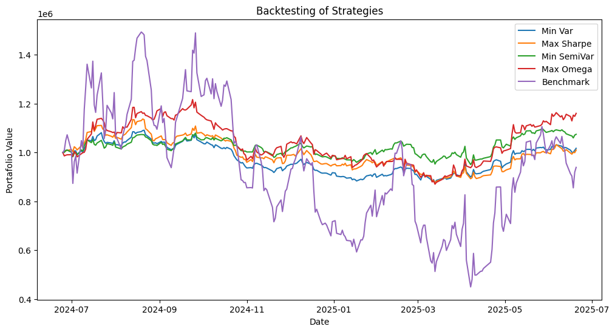

```python
evol = backtesting(bt_prices, benchmark, w_dict, capital=V_0)
```

```python
metricas = metricas_desempeño(evol, 0.04)
metricas
```

|  | Min Var | Max Sharpe | Min SemiVar | Max Omega | Benchmark |
| --- | --- | --- | --- | --- | --- |
| Rendimiento promedio anual | 3.063755 | 2.717795 | 8.673200 | 18.722521 | 60.712402 |
| Volatilidad Anual | 16.298030 | 18.440974 | 16.368070 | 26.702503 | 114.576493 |
| Ratio de Sharpe | 0.185529 | 0.145209 | 0.527442 | 0.699654 | 0.529536 |
| Downside Risk | 10.253701 | 11.738724 | 11.465138 | 16.355646 | 80.255964 |
| Upside Risk | 10.305211 | 11.860798 | 9.840445 | 18.943978 | 68.883113 |
| Omega | 1.005024 | 1.010399 | 0.858293 | 1.158253 | 0.858293 |
| Beta | 0.126168 | 0.116002 | 0.142857 | 0.131430 | 1.000000 |
| Alpha | -4.631154 | -4.360331 | -0.034286 | 10.708343 | 0.000000 |
| Ratio de Treynor | 23.966122 | 23.084021 | 60.432402 | 142.147991 | 60.672402 |
| Ratio de Sortino | 0.294894 | 0.228116 | 0.752996 | 1.142267 | 0.755986 |

**Análisis**

Los resultados muestran diferencias significativas en rendimiento, riesgo y eficiencia según el enfoque de optimización aplicado.

En términos de rendimiento promedio anual, el Benchmark alcanzó la mayor rentabilidad (60.7%), aunque con una volatilidad extremadamente alta (114.6%), lo que refleja un comportamiento agresivo y poco controlado del riesgo. En contraste, las estrategias optimizadas mantuvieron rendimientos más moderados con volatilidades muy inferiores. Dentro de ellas, Max Omega destacó con un rendimiento de 18.7% y una volatilidad de 26.7%, logrando un equilibrio entre rendimiento-riesgo.

Solo Max Omega obtuvo un Alpha positivo (10.7), evidenciando generación de valor por encima del rendimiento esperado según su riesgo.

**Selección de Estrategia de Inversión. (20%)**

Su Sharpe (0.70) y Sortino (1.14) muestran que ofrece mejores rendimientos por cada unidad de riesgo, sobre todo ante pérdidas. Además, su Alpha positivo (10.7) refleja que logra generar valor adicional frente al mercado.

En pocas palabras, elijo Max Omega** porque combina rendimientos sólidos con un manejo inteligente del riesgo. Es una estrategia que me permite crecer sin tener que ser demasiado agresiva, manteniendo el equilibrio que busco.

**Calculo de Pesos para Portafolio Real. (10%)**

```python
capital = 1000000
```

```python
re_opt = pd.DataFrame(index=  opt_rets.columns)
re_opt['w'] = max_omega(rets_bt)
re_opt['$'] = re_opt['w'] * capital
re_opt['#Acciones'] = np.floor(re_opt['$'] / bt_prices.iloc[-1])
re_opt
```

| Ticker | w | $ | #Acciones |
| --- | --- | --- | --- |
| CEMEXCPO.MX | 8.861657e-18 | 8.861657e-12 | 0.0 |
| CHDRAUIB.MX | 5.587053e-18 | 5.587053e-12 | 0.0 |
| CUERVO.MX | 0.000000e+00 | 0.000000e+00 | 0.0 |
| KOFUBL.MX | 1.000000e+00 | 1.000000e+06 | 5653.0 |
| LABB.MX | 1.106811e-16 | 1.106811e-10 | 0.0 |
| LIVEPOLC-1.MX | 0.000000e+00 | 0.000000e+00 | 0.0 |
| RA.MX | 6.523713e-17 | 6.523713e-11 | 0.0 |